# Math 32: Exploration 5

Sreeda Vemuri

19 July, 2020

In this `exploration`, you are asked to

- look at various examples of correlated data
- look at an example of Simpson’s Paradox
1. First,
   1. Type your name into the author field in the YAML parameters above
   2. Also save this file while replacing “template” with your full name (be sure to keep the *.rmd file format).

```r
# load useful code packages
library("dplyr")
library("ggplot2")

# a user-made function to create correlated values
# INPUTS: vector of x values,
#         desired correlation level (default = 0.9)
# OUTPUT: vector of y values
correlatedValues = function(x, r = 0.9){
  r2 = r**2
  ve = 1-r2
  SD = sqrt(ve)
  e  = rnorm(length(x), mean=0, sd=SD)
  y  = r*x + e
  return(y)
}

# create synthetic data for the Simpson's Paradox demonstration
x1 = rnorm(100, mean = -6, sd = 1)
y1 = correlatedValues(x1, r = 0.75) + 6
x2 = rnorm(100, mean = -3, sd = 1)
y2 = correlatedValues(x2, r = 0.75) + 3
x3 = rnorm(100, mean = 0, sd = 1)
y3 = correlatedValues(x3, r = 0.75)
x4 = rnorm(100, mean = 3, sd = 1)
y4 = correlatedValues(x4, r = 0.75) - 3
x5 = rnorm(100, mean = 6, sd = 1)
y5 = correlatedValues(x5, r = 0.75) - 6
df1 <- data.frame(x1, y1, "group 1")
df2 <- data.frame(x2, y2, "group 2")
df3 <- data.frame(x3, y3, "group 3")
df4 <- data.frame(x4, y4, "group 4")
df5 <- data.frame(x5, y5, "group 5")
names(df1) <- c("xdata", "ydata", "group")
names(df2) <- c("xdata", "ydata", "group")
names(df3) <- c("xdata", "ydata", "group")
names(df4) <- c("xdata", "ydata", "group")
names(df5) <- c("xdata", "ydata", "group")
main_df <- rbind(df1, df2, df3, df4, df5)
```

# Correlation

2. Read through and run the following example code block. Try to understand what the code does and demonstrate your understanding with (at least) 5 code comments.

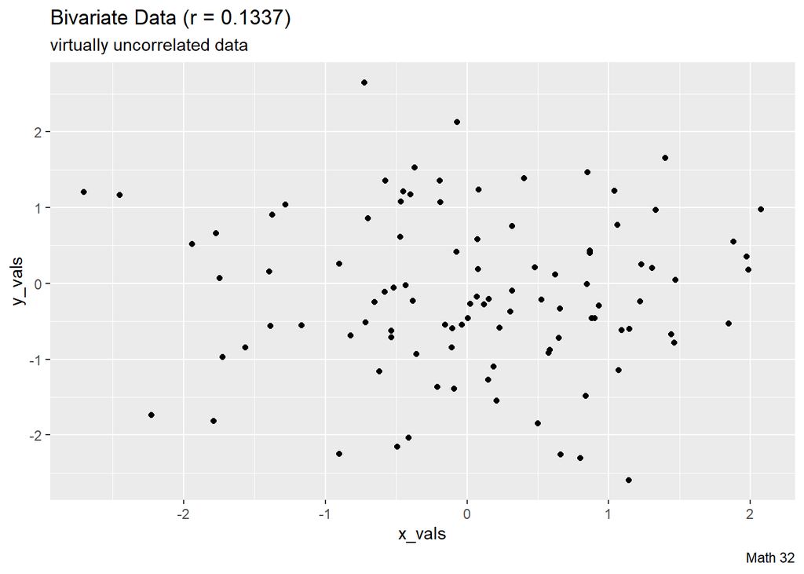

```r
r_val <- 0.1337
x_vals <- rnorm(100) #total 100 points on the plot
y_vals <- correlatedValues(x_vals, r = r_val)
temp_df <- data.frame(x_vals, y_vals) #
ggplot(temp_df, aes(x = x_vals, y = y_vals)) +
  geom_point() +
  labs(title = paste0("Bivariate Data (r = ", r_val, ")"),
       subtitle = "virtually uncorrelated data",
       caption = "Math 32")
```

3. Produce 4 graphs like the one above
- each in its own code block
- one example for each level of correlation in the table below
- place the respective description in the subtitle
- replace “Math 32” with your full name

| Correlation Value | Description |
| --- | --- |
| $-1 < r < -0.7$ | strongly and negatively correlated |
| $-0.7 < r < -0.4$ | weakly and negatively correlated |
| $0.4 < r < 0.7$ | weakly and positively correlated |
| $0.7 < r < 1$ | strongly and positively correlated |

[figure not shown]

```r
r_val <- -0.9
x_vals <- rnorm(100) #total 100 points on the plot
y_vals <- correlatedValues(x_vals, r = r_val)
temp_df <- data.frame(x_vals, y_vals) #
ggplot(temp_df, aes(x = x_vals, y = y_vals)) +
  geom_point() +
  labs(title = paste0("Bivariate Data (r = ", r_val, ")"),
       subtitle = "virtually uncorrelated data",
       caption = "Sreeda Vemuri")
```

[figure not shown]

```r
r_val <- -0.6
x_vals <- rnorm(100) #total 100 points on the plot
y_vals <- correlatedValues(x_vals, r = r_val)
temp_df <- data.frame(x_vals, y_vals) #
ggplot(temp_df, aes(x = x_vals, y = y_vals)) +
  geom_point() +
  labs(title = paste0("Bivariate Data (r = ", r_val, ")"),
       subtitle = "virtually uncorrelated data",
       caption = "Sreeda Vemuri")
```

[figure not shown]

```r
r_val <- 0.5
x_vals <- rnorm(100) #total 100 points on the plot
y_vals <- correlatedValues(x_vals, r = r_val)
temp_df <- data.frame(x_vals, y_vals) #
ggplot(temp_df, aes(x = x_vals, y = y_vals)) +
  geom_point() +
  labs(title = paste0("Bivariate Data (r = ", r_val, ")"),
       subtitle = "virtually uncorrelated data",
       caption = "Sreeda Vemuri")
```

[figure not shown]

```r
r_val <- 0.8
x_vals <- rnorm(100) #total 100 points on the plot
y_vals <- correlatedValues(x_vals, r = r_val)
temp_df <- data.frame(x_vals, y_vals) #
ggplot(temp_df, aes(x = x_vals, y = y_vals)) +
  geom_point() +
  labs(title = paste0("Bivariate Data (r = ", r_val, ")"),
       subtitle = "virtually uncorrelated data",
       caption = "Sreeda Vemuri")
```

4. Write (at least) two sentences to describe what you observe with the above visuals.

The Bivariable graph’s above have a different scatter for all of them, the only differece appears to that 2 are more clear than the other. The r’s that are closer to 1 are more clear in the distribution of the scatter.

# Simpsons Paradox

5. Run the next code block to get a sense of its calculations.

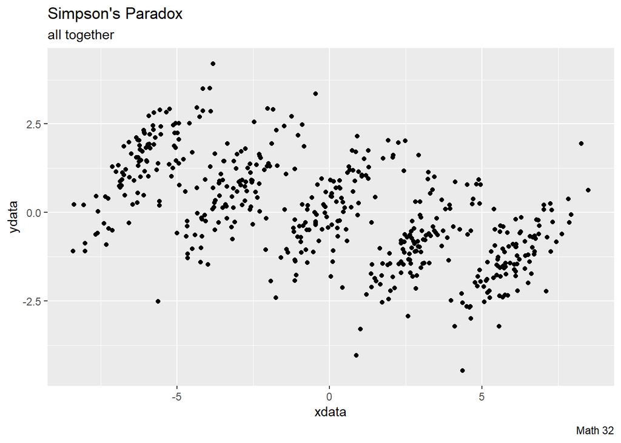

```r
main_df %>%
  ggplot(aes(x = xdata, y = ydata)) +
  geom_point() +
  labs(title = "Simpson's Paradox",
       subtitle = "all together",
       caption = "Math 32")
```

```r
# compute correlation
main_df %>%
  summarize(cor = cor(xdata, ydata))
```

```
##          cor
## 1 -0.5542539
```

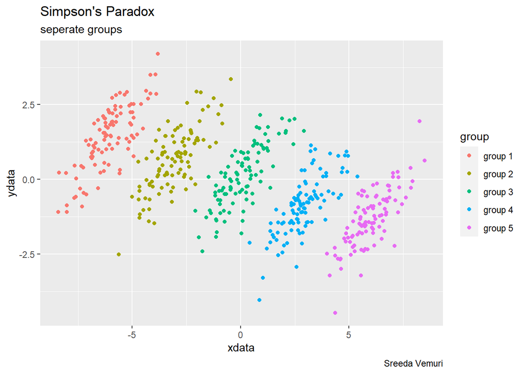

```r
main_df %>%
  group_by(group) %>%
  ggplot(aes(x = xdata, y = ydata, color = group)) +
  geom_point() +
  labs(title = "Simpson's Paradox",
       subtitle = "seperate groups",
       caption = "Sreeda Vemuri")
```

```r
# compute correlation
main_df %>%
   group_by(group) %>%
  summarize(cor = cor(xdata, ydata))
```

```
## # A tibble: 5 x 2
##   group     cor
##   <chr>   <dbl>
## 1 group 1 0.777
## 2 group 2 0.740
## 3 group 3 0.772
## 4 group 4 0.751
## 5 group 5 0.768
```

6. Repeat the previous code block, but
- add `color = group` in the ggplot aesthetics
- add `group_by(group) %>%` after each pipe operator
- replace the subtitle with “separate groups”
- replace “Math 32” with your full name
7. Write (at least) two sentences to describe what you observe in the above two sets of graphs and calculations.

In the first graph of the Simpson’s Paradox, the graph appeared to have a negative slope in the scatter. Whereas, in the 2nd scatter, there were 5 seperate “scatters” which all had a positive scatter slope.

8. Finally, `knit` your work as either an HTML or PDF document, and upload that document back into the CatCourses assignment.